# Step 2. Identifying POBs and checking data

3/19/2019

In this script we will work with the **NONPROFIT-2014-2019.rds** and **PEOPLE-2014-2019.rds** files to:

1. Identifying Addresses that are PO Boxes. POBs will be geocoded through their zips or city centroids
2. Exploring data gaps in the addresses data
3. Creating an input_address variable NEED TO UPDATE THIS IN THE SCRIPT

New datasets will be stored as **NONPROFIT-2014-2019v2.rds** and **PEOPLE-2014-2019v2.rds**. In addition address files **NPOAddresses_census.rds** and **PPLAddresses_census.rds** will be created to pass them through the Census Geocoding service.

# Packages

```r
library( dplyr )
library(tidyverse)
library( tidyr )
library( pander )
library( httr )
library( stringr )

#update the path with your working directory:
wd <- "/Users/icps86/Dropbox/R Projects/Open_data_ignacio"
setwd(wd)
dir()
```

```
##  [1] "_Archive"                       "Data"
##  [3] "Data2"                          "Documentation"
##  [5] "GeoProcessReport.html"          "GeoProcessReport.Rmd"
##  [7] "Icon\r"                         "Images"
##  [9] "Research Note"                  "Step-01-ProcessRawData.html"
## [11] "Step-01-ProcessRawData.Rmd"     "Step-02-POBsandGaps.html"
## [13] "Step-02-POBsandGaps.Rmd"        "Step-03-CensusGeo.Rmd"
## [15] "Step-03-fix.Rmd"                "Step-03.1-CensusGeo.html"
## [17] "Step-03.2-CompilingResults.Rmd" "Step-03.3-SecondCensusGeo.Rmd"
## [19] "Step-04-GoogleGeo.Rmd"          "Step-05-ZipsandCityGeo.Rmd"
## [21] "Step-06-Disambiguation.Rmd"     "StepsTable.fld"
## [23] "StepsTable.html"                "zip-codes"
```

# 1. Identifying PO Boxes

We will be looking for POB (Post Office Boxes). Might also find APOs (Army Post Office), FPOs (Fleet Post Office) and DPOs (Diplomatic Post Office).

## 1.1 Developing a regular expression code to identify PO Boxes

## 1.1 Identifying POBs in NPO dataset

Loading file and creating a POB variable to flag addresses that are pobs.

```r
#loading data
npo <- readRDS("Data/2_InputData/NONPROFITS-2014-2019.rds")

#creating a variable for pob flags
npo$pob <- NA
```

Identifying the pobs using a regular expression code

```r
x <- grepl("Post Office|POST OFFICE BOX|PO BOX|POBOX|BOX\\s*\\d|POB\\s*\\d|CPO\\s*\\d|PO B\\s*\\d|^PO\\s*\\d+$", npo$Address,ignore.case=TRUE)
pob <- npo$Address[which(x)]
head(pob, 5)
```

```
## [1] "P O BOX 284" "PO BOX 1111" "PO BOX 261"  "PO BOX 98"   "PO BOX 196"
```

Addressess identified as POBs are sometimes very lengthy…

```r
#including a character length var
pob.len <- nchar(pob)
pobs <- tibble(pob,pob.len)

#arranging it
pobs <- arrange(pobs, desc(pob.len))
head(pobs)
```

| pob | pob.len |
| --- | --- |
| 5705 MEMORIAL DRIVE - PO BOX 870068 | 35 |
| PO BOX 530 112 CITY CENTER DR | 35 |
| 801 EAST LINCOLN AVENUE - PO BOX 87 | 35 |
| PO BOX 751 - CPO - SOMA ECODISTRICT | 35 |
| 1282 SMALLWOOD DRIVE WEST BOX 401 | 35 |
| 12800 ARBOR LAKES PKWY PO BOX 1180 | 35 |

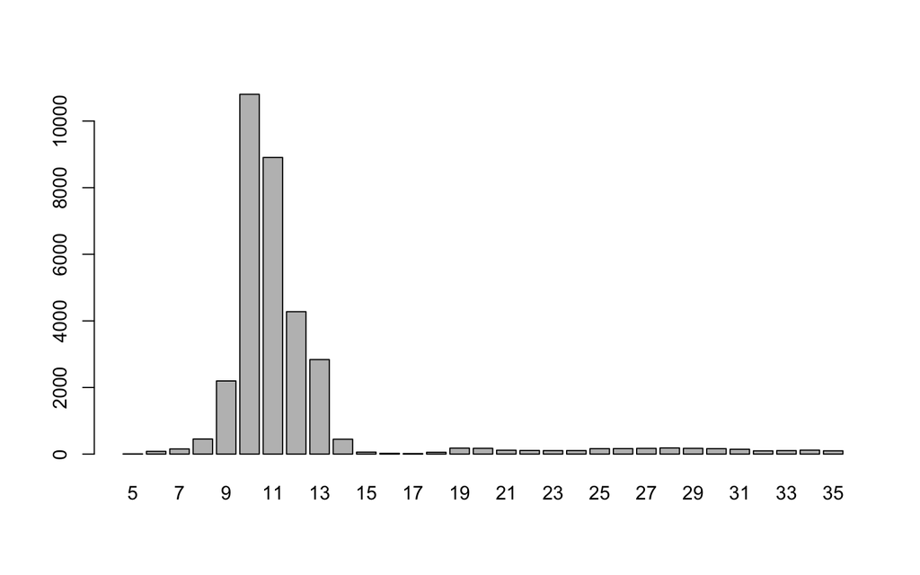

```r
#plotting
x <- table(pobs$pob.len)
barplot(x)
```

```r
pander(x[3:11])
```

| 7 | 8 | 9 | 10 | 11 | 12 | 13 | 14 | 15 |
| --- | --- | --- | --- | --- | --- | --- | --- | --- |
| 155 | 452 | 2197 | 10804 | 8907 | 4277 | 2838 | 446 | 60 |

Most NPO POB addresses are clusterd around the 11 character length.

After taking a closer look, we notice that lengthy POB addresses have a mix of both POB info and a regular address.

Take a look at POBs with 25 characters

```r
head(pobs[pobs$pob.len==25,], 5)
```

| pob | pob.len |
| --- | --- |
| 52 ABBEY ROAD PO BOX 2688 | 25 |
| PO BOX 202 - 825 YOUNG ST | 25 |
| 70 MOORE DRIVE/PO BOX 153 | 25 |
| 1019 MAIN STREET BOX 172 | 25 |
| 341 MAIN STREET PO BOX 88 | 25 |

A POB flag and address character length var will be added to the actual dataset

```r
#char length
npo$add.len <- nchar(npo$Address)

#pob flag
x <- grepl("Post Office|POST OFFICE BOX|PO BOX|POBOX|BOX\\s*\\d|POB\\s*\\d|CPO\\s*\\d|PO B\\s*\\d|^PO\\s*\\d+$", npo$Address,ignore.case=TRUE)
npo$pob <- as.numeric(x) #adding a flag for pobs identified
```

How many pobs?

```r
x <- as.data.frame(prop.table(table(npo$pob)))
names(x) <- c("pob","percent")
x$percent <- paste0(round(x$percent*100,1)," %")
pander(x)
```

| pob | percent |
| --- | --- |
| 0 | 87.6 % |
| 1 | 12.4 % |

We will merge the ADDRESS, CITY, STATE and ZIP variable to create an INPUT ADDRESS var in the NPO dataset for geocoding.

```r
#creating an Input Address variable
npo$input_address <- paste(npo$Address, npo$City, npo$State, npo$Zip, sep = ", ")
```

Saving the npo file

```r
saveRDS(npo, "Data/2_InputData/NONPROFITS-2014-2019v2.rds")
```

## 1.2 Identifying POBs in BOARD MEMBERS dataset

Loading file and creating a pob variable to flag addresses that are pobs.

```r
#loading data
ppl <- readRDS("Data/2_InputData/PEOPLE-2014-2019.rds")

#creating a variable for pob flags
ppl$pob <- NA
```

Identifying the pobs using a regular expression code

```r
x <- grepl("Post Office|POST OFFICE BOX|PO BOX|POBOX|BOX\\s*\\d|POB\\s*\\d|CPO\\s*\\d|PO B\\s*\\d|^PO\\s*\\d+$", ppl$Address,ignore.case=TRUE)
pob <- ppl$Address[which(x)]
head(pob, 5)
```

```
## [1] "P O BOX 1742" "RR2 BOX 6464" "PO BOX 7"     "PO BOX 7"     "PO BOX 7"
```

Similar to the NPO addresses, some POBs are mixedwith regular address info:

```r
pob.len <- nchar(pob)
pobs <- tibble(pob,pob.len)
pobs <- arrange(pobs, desc(pob.len))
head(pobs)
```

| pob | pob.len |
| --- | --- |
| INSTITUTE OF HUMAN DEV NAU BOX 5630 | 35 |
| 10730 POTRANCO RD SUITE 122 BOX 125 | 35 |
| 1282 SMALLWOOD DRIVE WEST BOX 401 | 35 |
| 1282 SMALLWOOD DRIVE WEST BOX 401 | 35 |
| 1282 SMALLWOOD DRIVE WEST BOX 401 | 35 |
| 1282 SMALLWOOD DRIVE WEST BOX 401 | 35 |

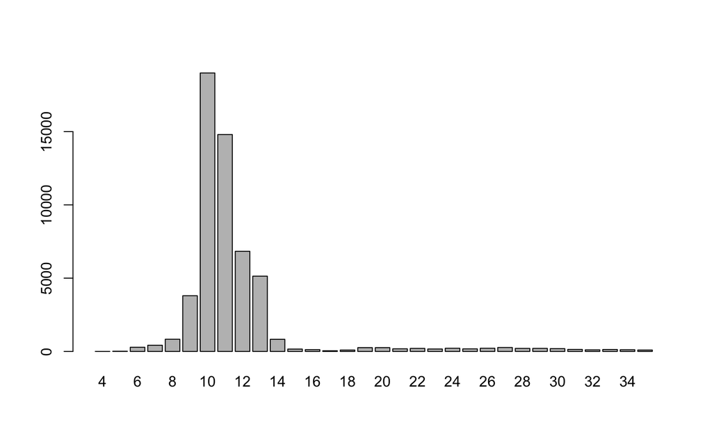

```r
#plotting
x <- table(pobs$pob.len)
barplot(x)
```

```r
pander(x[4:12])
```

| 7 | 8 | 9 | 10 | 11 | 12 | 13 | 14 | 15 |
| --- | --- | --- | --- | --- | --- | --- | --- | --- |
| 422 | 834 | 3801 | 19002 | 14801 | 6833 | 5138 | 826 | 160 |

Most ppl POB addresses are also clusterd around the 11 character length.

Adding POB flag and add.len var

```r
ppl$add.len <- nchar(ppl$Address)

x <- grepl("Post Office|POST OFFICE BOX|PO BOX|POBOX|BOX\\s*\\d|POB\\s*\\d|CPO\\s*\\d|PO B\\s*\\d|^PO\\s*\\d+$", ppl$Address,ignore.case=TRUE)
ppl$pob <- as.numeric(x) #adding a flag for pobs identified
```

How many pobs?

```r
x <- as.data.frame(prop.table(table(ppl$pob)))
names(x) <- c("pob","percent")
x$percent <- paste0(round(x$percent*100,1)," %")
pander(x)
```

| pob | percent |
| --- | --- |
| 0 | 94.1 % |
| 1 | 5.9 % |

We will merge the ADDRESS, CITY, STATE and ZIP variables to create an INPUT ADDRESS var in the ppl dataset for geocoding.

```r
#creating an Input Address variable
ppl$input_address <- paste(ppl$Address, ppl$City, ppl$State, ppl$Zip, sep = ", ") #creating an input_address field to match the geocode dataframes
```

Saving rds

```r
saveRDS(ppl, "Data/2_InputData/PEOPLE-2014-2019v2.rds")
```

# 2. Exploring Address data gaps

In this section we will look into the Addresses and try to identify any problem with the data. We will also create an address_input variable which will be used for geocoding.

## 2.1 NonProfit dataset

The variables that contain address informaiton are:

- “Address”
- “City”
- “State”
- “Zip”

Subsetting a smaller file to explore addresses, removing pobs

```r
nmz <- c("ID", "ORGNAME", "Address", "City", "State", "Zip", "pob", "add.len")
add <- npo[,nmz]

#dropping all pobs
x <- add$pob == 0
add <- add[x,]
```

- NPO **ADDRESSES** have 3 NAs and 0 blanks

Using the Address character length variable (add.len) to see the distribution and determine when an address is short enough to assume it is unintelligible.

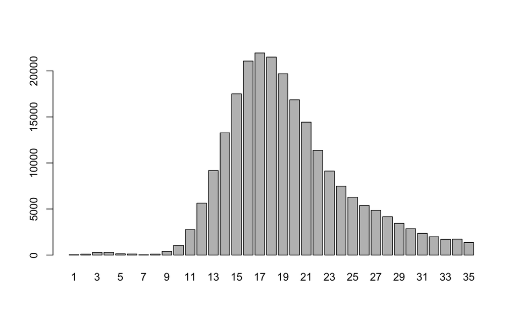

```r
x <- table(add$add.len)
barplot(x)
```

```r
x[13:21]
```

```
##
##    13    14    15    16    17    18    19    20    21
##  9176 13270 17502 21068 21944 21499 19681 16861 14434
```

NPO Addresses are clustered around 18 characters

Addresses with length 1-2 are unintelligible and will probably have to be geocoded using zip codes or city centers

```r
x <- which(add$add.len %in% c(1,2))
head(add$Address[x],15)
```

```
##  [1] "68" "38" "26" "4"  "68" "E"  "55" "PO" "32" "81" "N"  "13" "79" "91" "24"
```

Looking at those with length 3-4, they still look unintelligible

```r
x <- which(add$add.len %in% c(3,4))
head(add$Address[x],15)
```

```
##  [1] "573"  "332"  "7472" "1377" "7232" "564"  "659"  "463"  "567"  "339"
## [11] "734"  "782"  "7235" "3815" "6003"
```

Addresses with length 5-6 also seem to be numbers with not much sense

```r
x <- which(add$add.len %in% c(5,6))
head(add$Address[x],15)
```

```
##  [1] "20832"  "66612"  "720038" "330322" "12492"  "11855"  "530591" "490141"
##  [9] "950691" "26957"  "65482"  "11065"  "42368"  "342341" "65745"
```

However, looking at those with length 7-8, we start to recognize proper addressess.

```r
x <- which(add$add.len %in% c(7,8))
head(add$Address[x],15)
```

```
##  [1] "C/O 356"  "P O 4911" "HWY 37 N" "919 BERT" "218 LAWN" "276 KING"
##  [7] "45 TESLA" "45 TESLA" "408 J ST" "301 UCB"  "SUITE 8"  "3 DEODAR"
## [13] "832 30TH" "49 RR 2"  "497 MAIN"
```

Looking for NAs within the other relevant columns

- **CITY** variable has 11 NAs and 1 blanks

City var has some unintelligible values

```r
x <- as.data.frame(table(add$City, useNA = "always"))
names(x)[1] <- "City"
x <- arrange(x, City)
x$City[1:50]
```

```
##  [1] , ANTIOCH            , MONTCLAIR          :AGRANGE
##  [4] :LITHONIA            `                    07013
##  [7] 08088-000            0WASSO               1.   PACOIMA
## [10] 11231                13035 OLIVE BLVD     1474 BERGER DR
## [13] 20748                2212 SW 55TH         33162
## [16] 37 WOODS DRIVE       3A                   45434
## [19] 46TH COURT           48723                50309
## [22] 50674                54911                63103
## [25] 63136                76052                77004
## [28] 818 FARMERS UNION RD 93420                A
## [31] AARONSBURG           ABBEVILLE            ABBOTTSTOWN
## [34] ABEDEEEN             ABERDEEN             ABERNATHY
## [37] ABIENE               ABILENE              ABINGDON
## [40] ABINGTON             ABIQUIU              ABITA SPRINGS
## [43] ABRAMS               ABSAROKEE            ABSECON
## [46] ACAMPO               ACCIDENT             ACCOKEEK
## [49] ACCORD               ACKERLY
## 14515 Levels: , ANTIOCH , MONTCLAIR :AGRANGE :LITHONIA ` 07013 ... ZWOLLE
```

And some values that seem to be too short or too long

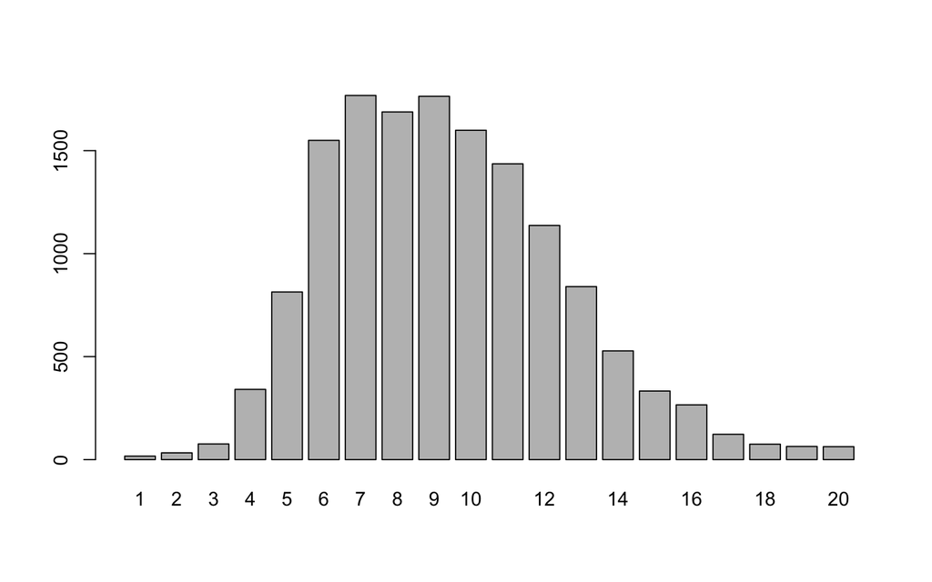

```r
x$City <- as.character(x$City)
x$len <- nchar(x$City)
barplot(table(x$len))
```

```r
x <- arrange(x, len)
head(x$City,20)
```

```
##  [1] "`"  "A"  "B"  "C"  "D"  "E"  "F"  "G"  "H"  "I"  "M"  "N"  "O"  "Q"  "R"
## [16] "S"  "W"  "3A" "AR" "AS"
```

```r
tail(x$City,15)
```

```
##  [1] "SOUTHEAST WASHINGTON" "SPOTSYLVANIA COURTHO" "SUMMERVILLE / LINCOL"
##  [4] "THOUSAND ISLAND PARK" "TRUTH OR CONSEQUENCE" "UNION MILLSUNION MIL"
##  [7] "VIRGINVIRGINIA BEACH" "WARRENSVILLE HEIGHTS" "WASHINGTON COURT HOU"
## [10] "WASHINGTON COURTHOUS" "WESLEY HILLS, NY 109" "WEST CHESTER TOWNSHI"
## [13] "WHITE RIVER JUNCTION" "WHITE SULPHUR SPRING" NA
```

- **STATE** variable has 47 NAs and 1

State variable seems more standard

```r
sort(unique(add$State))
```

```
##  [1] "AA" "AE" "AK" "AL" "AP" "AR" "AS" "AZ" "CA" "CO" "CT" "DC" "DE" "FL" "FM"
## [16] "GA" "GU" "HI" "IA" "ID" "IL" "IN" "KS" "KY" "LA" "MA" "MD" "ME" "MH" "MI"
## [31] "MN" "MO" "MP" "MS" "MT" "NC" "ND" "NE" "NH" "NJ" "NM" "NV" "NY" "OH" "OK"
## [46] "OR" "PA" "PR" "PW" "RI" "SC" "SD" "TN" "TX" "UM" "UT" "VA" "VI" "VT" "WA"
## [61] "WI" "WV" "WY"
```

- **ZIP** variable has 0 NAs and 0

## 2.2 Board Member dataset

Subsetting a smaller file, and removing pobs

```r
nmz <- c("ID", "ORGNAME", "Address", "City", "State", "Zip", "pob", "add.len")
add <- ppl[,nmz]

#dropping all pobs
x <- add$pob == 0
add <- add[x,]
```

- PPL **ADDRESSES** have 403 NAs and 0 blanks

Using the Address character length variable (add.len) to see the distribution

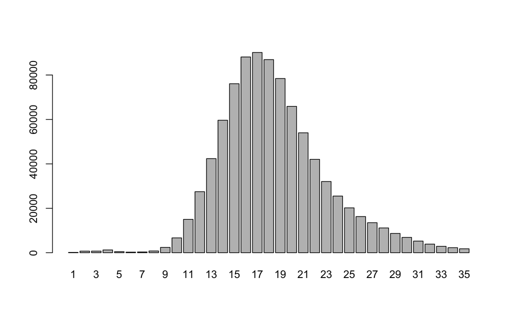

```r
x <- table(add$add.len)
barplot(x)
```

```r
x[13:22]
```

```
##
##    13    14    15    16    17    18    19    20    21    22
## 42360 59642 76075 88122 90147 86933 78423 65886 53984 42045
```

PPL Addresses are clustered around 18 characters.

Similar to NPO data, shorter addresses are unintelligeble.

```r
x <- which(add$add.len %in% c(1,2))
head(add$Address[x],15)
```

```
##  [1] "-"  "E"  "24" "24" "NA" "NA" "NA" "7"  "2"  "NA" "NA" "5"  "NA" "-"  "-"
```

```r
x <- which(add$add.len %in% c(3,4))
head(add$Address[x],15)
```

```
##  [1] "NONE" "2832" "230"  "NONE" "RT 2" "VOID" "1655" "RR 4" "171"  "564"
## [11] "564"  "564"  "564"  "564"  "NONE"
```

```r
x <- which(add$add.len %in% c(5,6))
head(add$Address[x],15)
```

```
##  [1] "20832"  "20832"  "20832"  "20832"  "14421"  "DUEBER" "12950"  "11022"
##  [9] "44744"  "ARROYO" "ARROYO" "530591" "530591" "530591" "530591"
```

And, again, Addresses with length 7-8 are recognizable as proper addressess.

```r
x <- which(add$add.len %in% c(7,8))
head(add$Address[x],20)
```

```
##  [1] "SERETARY" "59 WATER" "107 N ST" "3 JORDAN" "SOUTH ST" "GRAND ST"
##  [7] "POLK AVE" "510 HYDE" "512 PARK" "108 POLO" "HEATHER"  "RR3 H-21"
## [13] "RR3 H-21" "8 ALDEN"  "16CR329"  "ELM PARK" "3726 RFD" "5500 IDA"
## [19] "372ND ST" "POBX 387"
```

Looking for NAs within the other relevant columns

- **CITY** variable has 220 NAs and 0 blanks

City var has some unintelligible values

```r
x <- as.data.frame(table(add$City, useNA = "always"))
names(x)[1] <- "City"
x <- arrange(x, City)
x$City[1:50]
```

```
##  [1] -                    --                   , LAKELAND
##  [4] , LEWISVILLE         , LINCOLNWOOD        , SAN JOSE
##  [7] , SOUTH OZONE PARK   ,ISSOURI CITY        ,MARLTON
## [10] ,MARSHALL            ,MOKENA              ;MARION
## [13] :BARRE               :LAS VEGAS           :LEWISVILLE
## [16] :LOS ANGELES         . BOULDER            . FULLERTON
## [19] . PHOENIX            .CLARENCE            'WESTFIELD
## [22] / LEXINGTON,         /COLORADO SPRINGS    /JONESBORO
## [25] /SOUTHFIELD          /WADMALAW ISLAND     0
## [28] 0750 OSLO NORWAY     0RLANDO              0XFORD
## [31] 0XNARD               1 NORMAL AVE         1000 VILLA ST
## [34] 102ND ST             10301                10454
## [37] 106 SE 7TH AVENUE    1071 SOUTHERN ARTERY 1101 W VICKSBURG PL
## [40] 11019 SLATER AVE     1107 FAIR OAKS AVE N 1109 WALNUT CIRCLE
## [43] 1111111              1112 WESTMINSTER AVE 11201
## [46] 11370 SE 33RD AVE    1155 STEVEN DR       116 31 STOCKHOLM SWE
## [49] 11701 NORTH WEST 12T 1205
## 26935 Levels: - -- , LAKELAND , LEWISVILLE , LINCOLNWOOD ... ZWOLLE
```

And some values that seem to be too short or too long

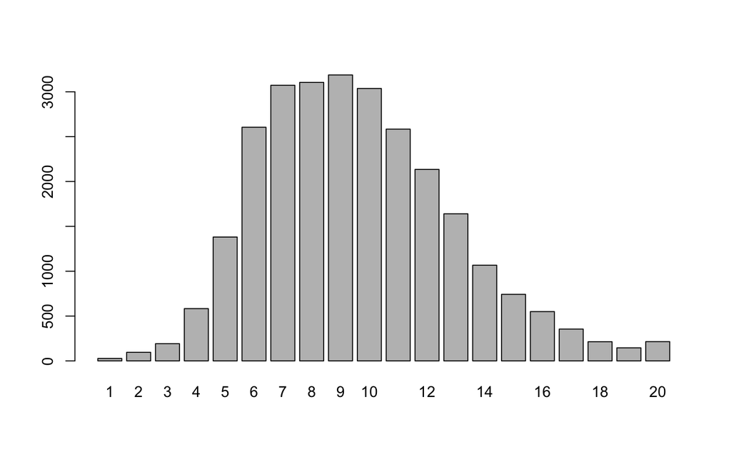

```r
x$City <- as.character(x$City)
x$len <- nchar(x$City)
barplot(table(x$len))
```

```r
x <- arrange(x, len)
head(x$City,20)
```

```
##  [1] "-" "0" "2" "A" "b" "B" "C" "D" "E" "F" "G" "H" "J" "K" "L" "M" "N" "O" "P"
## [20] "Q"
```

```r
tail(x$City,15)
```

```
##  [1] "WASHINGTON COURTHOUS" "WEST CHESTER, PA 193" "WEST PALM BEACH, FLO"
##  [4] "WEST PALWEST M BEACH" "WESTMORELAND JAMAICA" "WHITE RIVER JUNCTION"
##  [7] "WHITE SULFUR SPRINGS" "WHITE SULPHUR SPRING" "WILLOUGHBY HILLS APT"
## [10] "WILMINGTON, DE 19801" "WOKINGHAM RG402DH UK" "WOKINGHAM RG412YH UK"
## [13] "WORRINGHAM, ZIMBABWE" "YOKOHAMA CITY, JAPAN" NA
```

- **STATE** variable has 1484 NAs and 0 blanks

State variable seems more standard

```r
sort(unique(add$State))
```

```
##  [1] "AA" "AE" "AK" "AL" "AP" "AR" "AS" "AZ" "CA" "CO" "CT" "DC" "DE" "FL" "FM"
## [16] "GA" "GU" "HI" "IA" "ID" "IL" "IN" "KS" "KY" "LA" "MA" "MD" "ME" "MH" "MI"
## [31] "MN" "MO" "MP" "MS" "MT" "NC" "ND" "NE" "NH" "NJ" "NM" "NV" "NY" "OH" "OK"
## [46] "OR" "PA" "PR" "PW" "RI" "SC" "SD" "TN" "TX" "UM" "UT" "VA" "VI" "VT" "WA"
## [61] "WI" "WV" "WY"
```

- **ZIP** variable has 3024 NAs and 0 blanks

# 3. Creating Addresses files to pass through the Census Geocode service

For the Census geocoding, addresses should be formatted in the following fields:

- Unique ID,
- House Number and Street Name,
- City,
- State,
- ZIP Code

CREATING Address files **NPOAddresses_census.rds** and **PPLAddresses_census.rds**

## 3.1 Creating a NPO input_address dataset

```r
# npo <- readRDS( "Data/2_InputData/NONPROFITS-2014-2019v2.rds" )

npo$input_address <- paste(npo$Address, npo$City, npo$State, npo$Zip, sep = ", ") #creating an input_address field to match the geocode dataframes
npo <- npo[,c(1,73,12:15,71)]
npo$ID <- 0
npo <- unique(npo)
npo <- npo[order(npo$input_address),]
npo$ID <- 1:nrow(npo)
rownames(npo) <- NULL

saveRDS(npo, "Data/3_GeoCensus/NPOAddresses_census.rds")
```

## 3.2 Creating a PPL input_address dataset

```r
# ppl <- readRDS( "Data/2_InputData/PEOPLE-2014-2019v2.rds" )

ppl$input_address <- paste(ppl$Address, ppl$City, ppl$State, ppl$Zip, sep = ", ") #creating an input_address field to match the geocode dataframes

ppl <- ppl[,c(1,21,11:14,19)]
ppl$ID <- 0
ppl <- unique(ppl)

ppl <- ppl[order(ppl$input_address),]
ppl$ID <- 1:nrow(ppl)
rownames(ppl) <- NULL

saveRDS(ppl, "Data/3_GeoCensus/pplAddresses_census.rds")
```